- Menu

  Getting Started Creating an Assignment Creating and Managing Rubrics Grading Assignments Student View More Resources

  [Download PDF version](https://drive.google.com/file/d/1vyRbPHGFl5-1IOi6NAxauZpUyWI01bgF/view?usp=sharing)

# Blackboard Assignments and Rubrics

`Raw text` = What to click on or type in your computer (can be copy-pasted)  
Links = Clickable links

# Getting Started

Assignments are an appropriate tool for student work that is more complex than typing responses to question prompts. This tool can be used for submitting papers, lab reports, problem sets, or something similar. It can also be used for the submission of more complex assignments (e.g., programming or coding assignments), but keep in mind that these files will need to be downloaded for grading purposes – that is, not all file types can be “previewed” in the grading area.

# Creating an Assignment

Navigate to the area in Blackboard you wish to add your assignment. Hover over `Assessments` and select `Assignment`. Give your assignment a name. You can either type out instructions for the students, or you can attach instructions via the `Assignment Files` section. If you select a due date, submissions after this date *will be accepted*, but marked late.

Under `Grading`, indicate the maximum points possible or select a rubric. (See the section on `Rubrics` for more detailed information on creating and using these tools.)

`Submission Details` allows you to select from the following options:

1. `Individual or Group Assignment`: For a group assignment, you must already have groups of students created. (This is done in the `Users and Groups` area.)
2. `Number of Attempts`: How many times the student can submit work.
3. `Plagiarism Tools`: SafeAssign and related settings.

`Grading Options` allow the use of tools like anonymous grading (student names are hidden), or delegated grading to assign the task of grading to a specific user.

`Display of Grades` includes settings on how students grades will appear in grade center (score, percentage, etc.), and whether or not this should be included in the students’ grade totals. Usually these settings will be kept as is.

If you wish to have a firm deadline (no late submissions), limit the availability of the assignment so that students cannot see it once the deadline passes.

Once your assignment is created, you can click on the link (your assignment name) to preview how it will look for students. Students will also access the assignment and upload their files by clicking on this link.

# Creating and Managing Rubrics

Rubrics are a useful tool for grading assignments that have standardized criteria. They can also streamline the grading process and provide transparency for students.

## Creating Rubrics

Rubrics can be created in two ways. One way is to add them within the assignment itself by selecting `Add Rubric` and `Create New Rubric`. Another way is to navigate to `Course Tools` $→$ `Rubrics` and select `Create Rubric`.

Follow this general procedure for creating a rubric:

1. Give the rubric a meaningful name.
2. Use points instead of percentages by selecting `Points` from the `Rubric Type` drop-down menu.
3. Columns or rows can be added using the buttons at the top labeled `Add Row` or `Add Column`.
4. Columns indicate achievement levels. The existing columns can be edited by selecting the grey carrot and choosing `Edit`. They can also be deleted from this menu.
5. Rows indicate the varying assignment components. The rows in the final column (highest achievement) will be added together by Blackboard to determine the total point value of the assignment.
6. Use the `Point` boxes to indicate the appropriate number of points for each assignment component and level of achievement. You may also fill out the boxes (as below) with explanations of each level.

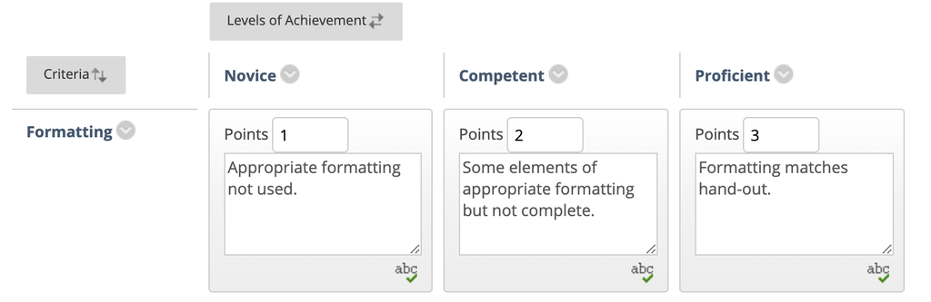

If you create the rubric from within the assignment, upon clicking `Submit` you’ll see a message that states `Click OK to assign the rubric's Maximum Points as the Points Possible`. You can select `OK`, or you can select `cancel` and manually set the point values. If your rubric contains 30 possible points but your assignment is manually set to be out of 10 points, Blackboard will weight each item accordingly to accommodate your chosen max score.

## Attaching Rubrics to an Assignment

The rubric can be created from within the assignment (as above), or it can be created in the `Rubrics` section and added by selecting `Select Rubric`.

Under `Show Rubric to Students` you may select from a variety of options depending on whether or not you want the students to see the rubric, or when you would like them to see it. If you select `Yes (With Rubric Scores)` students will be able to view the rubric from within the assignment prior to submission. They will also be able to see which achievement level they received for each criteria after grading is complete. (More on grading with rubrics in the section on below.)

## Managing Rubrics

To add, edit, or delete a rubric, head to `Course Tools` $→$ `Rubrics`. You may also delete a rubric from an assignment by clicking the red “X” next to it when you are editing an assignment.

# Grading Assignments

## Viewing Student Attempts

From within Grade Center, select the grey carrot next to the assignment name (i.e., the appropriate column). Click `Grade Attempts`. Once you complete grading your first assignment and select `Submit`, the next assignment will appear. (You may also click `Grade With User Names Hidden` for anonymous grading.)

To see an individual student’s attempt, click on the grey carrot next to the assignment in their row in Grade Center. An ungraded assignment will have a yellow exclamation point to indicate that the assignment needs grading. Select `View Attempt`.

## Leaving Feedback

The toolbar at the top of the grading area includes several options for leaving feedback. You can annotate the assignment (choose the picture of a paper and pen) by free-hand drawing, leaving an image or text box, or drawing other shapes. The `Comment` feature allows you to type comments in particular places.

You can also leave general comments in the box titled `Feedback to Learner`. As long as the assignment column is visible in Grade Center, students will be able to view any of your annotations or comments, as well as the general feedback by going to `My Grades`.

## Grading with Rubrics

To view your rubric, find the small blue line below the `Attempt` grade box. Click on the blue line. From there, click on your rubric. (See the images below for how this visually progresses.)

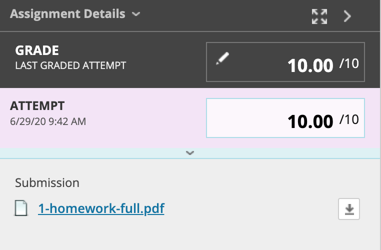

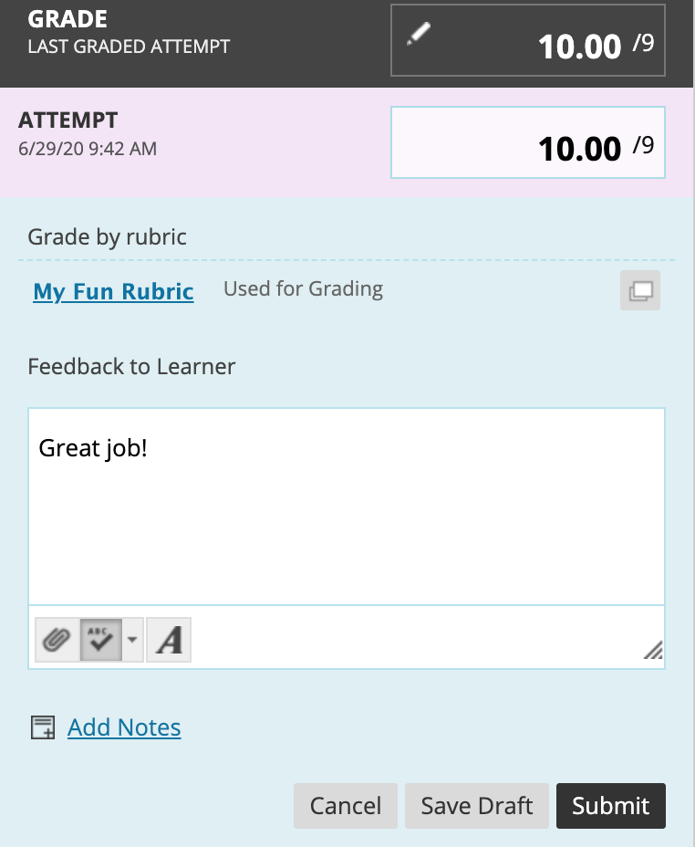

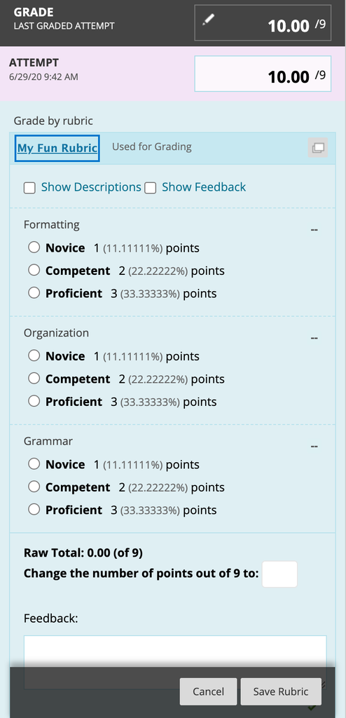

Once your rubric is visible, you can select on the appropriate achievement level for the student and leave feedback for each criteria. (Check the boxes `Show Description` and `Show Feedback` at the top of the rubric.) If you selected the option to show the students the rubric with scores, they will be able to see which achievement level was selected and all written feedback.

## Batch Downloads

If your assignment is a file-type that cannot be previewed in Blackboard, you’ll need to download the assignments to view them. You can do this in bulk by navigating to the assignment column in Grade Center, selecting the grey carrot, and choosing `Assignment File Download`. To choose all, click `Show All` (at the bottom) and then choose the checkbox at the very top next to `Name`. Click `Submit` and then `Download Assignments Now`. You can then open the .zip file and see the files within.

# Student View

Students receive an auto-generated Blackboard email when their assignment has been successfully submitted. They also receive a confirmation ID for each submission.

Students can go to `My Grades` and click on the assignment. From there, they will be able to see all the annotations on their assignment (if applicable), as well as the rubric. To see the rubric, they must click the box inside the `Attempt` area, shown below:

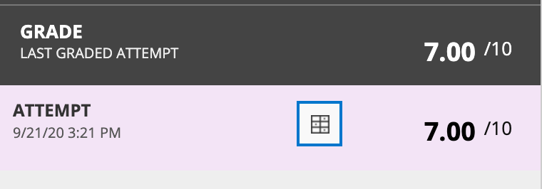

A pop-up appears with each rubric selection and any written feedback added by the grader.

*Note: Students are not able to view feedback if the column in Grade Center is hidden.*

# More Resources

- [ACCC quick-guide for Bb Assignment set-up](https://drive.google.com/file/d/1cQiVXKMnDQ45v8l3B8DP5kHIxH5iv7LI/view?usp=sharing)
- [Bb help page for Assignments](https://help.blackboard.com/Learn/Instructor/Assignments/Create_and_Edit_Assignments)
- [YouTube video on Bb Assignments](https://www.youtube.com/watch?v=hUXXCp1pnHs&feature=emb_logo&ab_channel=BlackboardInc.)
- [YouTube video on creating Bb Rubrics](https://www.youtube.com/watch?v=VgKIkeo-t3Q&t=1s)